# Importing and Processing CSV Files

Marc Los Huertos

12/6/2016

## Importing CSV Files

First, we will import the CSV file. In most cases, we don’t need to preprocess the csv files.

```r
# Importing Scripts

file = "/home/CAMPUS/tgpv2015/github/Climate Change Narratives/Data/denver1-TP.csv"

import = read.csv(file)
```

## Checking the Data

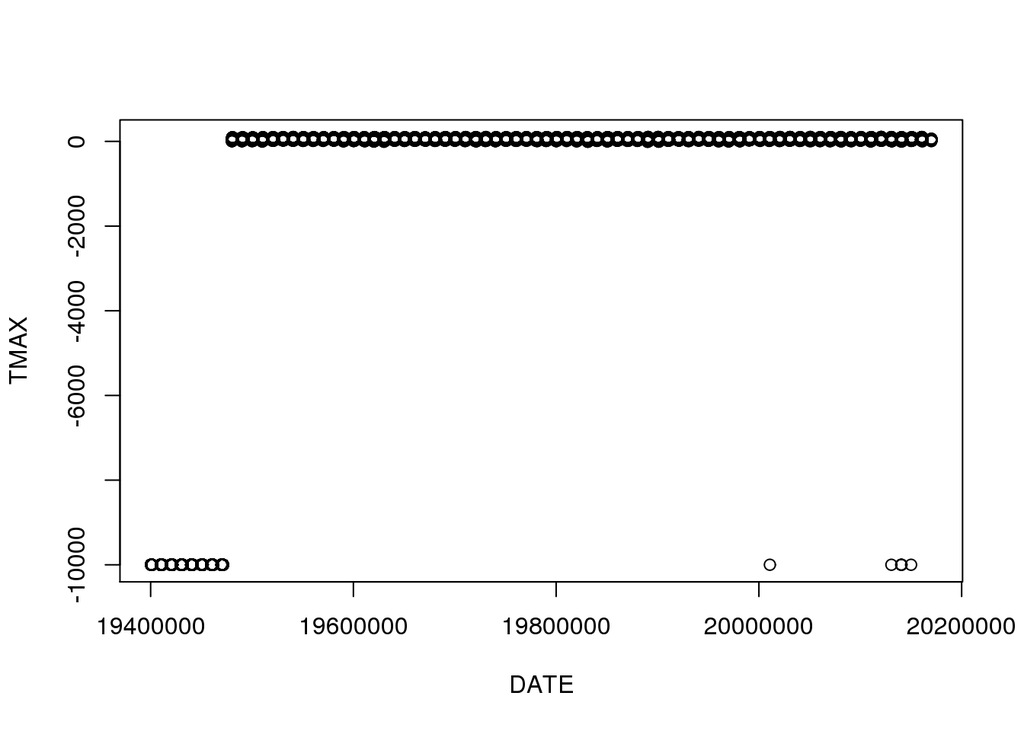

```r
plot(TMAX~DATE, import)
```

What’s going on? What is the deal with the -9999? These are used for missing data. We need to remove them!

```r
import$TMAX[import$TMAX==-9999] = NA
import$TMIN[import$TMIN==-9999] = NA
```

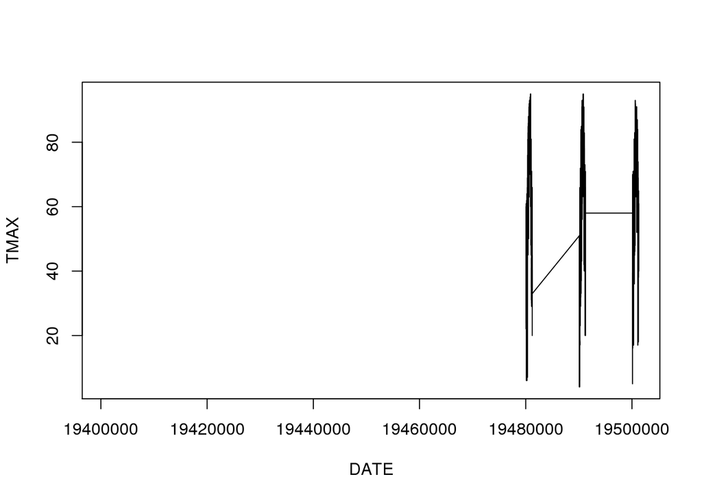

```r
plot(TMAX~DATE, import[import$DATE<19501231,], ty='l')
```

Yikes! What’s wrong? As it turns it the problem is that with how the dates are specified. In particular, the Dec 31 to Jan 1 transition:

19131231 -> 19140101, if you use these as numbers it should be 19131232, 19131232, etc. You see we are missing lots numbers!

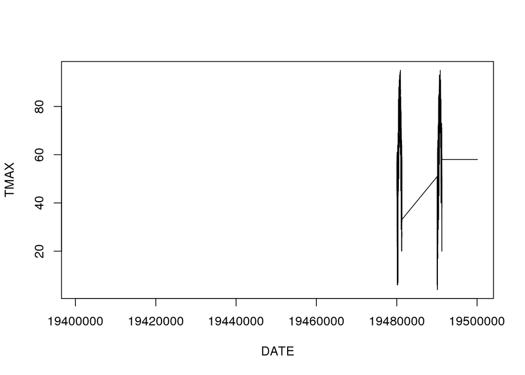

```r
plot(TMAX~DATE, import[import$DATE<19500102,], ty='l')
```

## Fixing the Dates

First, we convert the date a string or character values. Next, we’ll convert the strings to a data format.

```r
strDates <- as.character(import$DATE)
head(strDates)
```

```
## [1] "19400515" "19400516" "19400517" "19400518" "19400519" "19400520"
```

```r
import$NewDate <- as.Date(strDates, "%Y%m%d")
```

## Checking the New Dates

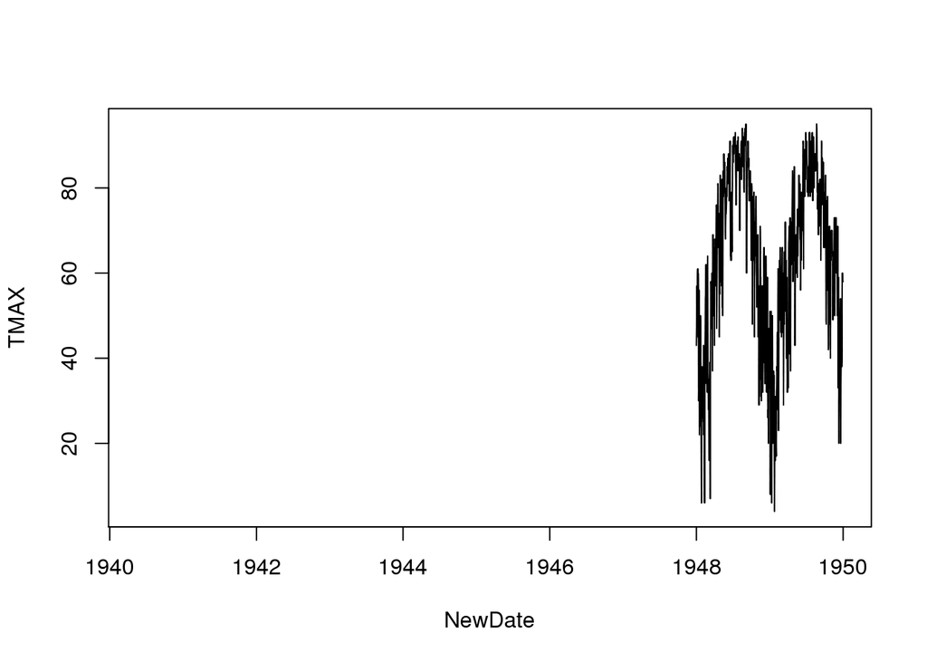

```r
plot(TMAX~NewDate, import[import$DATE<19500102,], ty='l')
```

## Subset Sites

```r
unique(import$STATION_NAME)
```

```
## [1] DENVER STAPLETON CO US
## Levels: DENVER STAPLETON CO US
```

```r
LosAngeles <- subset(import, STATION_NAME=="DENVER STAPLETON CO US", select=c(STATION, STATION_NAME, DATE, NewDate, TMIN, TMAX, PRCP))
```

## A new plot

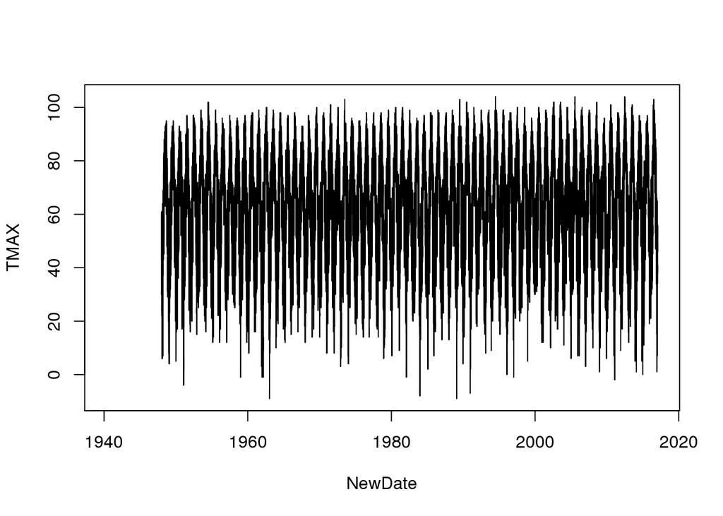

```r
plot(TMAX~NewDate, LosAngeles, ty='l')
```

## Evaluating the trend

Creating a linear model and then evaluate the rate (slope).

```r
# Linear Model
LosAngeles.lm <- lm(TMAX~NewDate, data=LosAngeles)
summary(LosAngeles.lm)
```

```
##
## Call:
## lm(formula = TMAX ~ NewDate, data = LosAngeles)
##
## Residuals:
##    Min     1Q Median     3Q    Max
## -73.64 -14.22   1.07  16.71  39.26
##
## Coefficients:
##              Estimate Std. Error t value Pr(>|t|)
## (Intercept) 6.427e+01  1.461e-01 440.076  < 2e-16 ***
## NewDate     5.240e-05  1.701e-05   3.081  0.00207 **
## ---
## Signif. codes:  0 '***' 0.001 '**' 0.01 '*' 0.05 '.' 0.1 ' ' 1
##
## Residual standard error: 19.64 on 25184 degrees of freedom
##   (2592 observations deleted due to missingness)
## Multiple R-squared:  0.0003768,  Adjusted R-squared:  0.0003371
## F-statistic: 9.493 on 1 and 25184 DF,  p-value: 0.002065
```

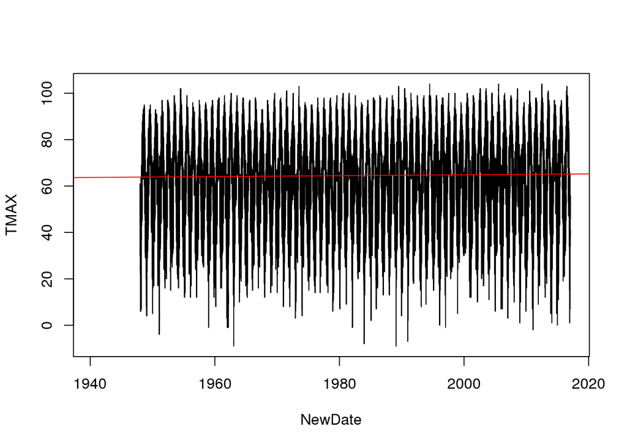

```r
plot(TMAX~NewDate, LosAngeles, ty='l')
abline(coef(LosAngeles.lm), col='red')
```

## Creating Month and Year Variables

So, let’s figure out how to see how changes happen for individual months.

```r
# Get months
LosAngeles$Month = months(LosAngeles$NewDate) # Creates problems.
LosAngeles$Month = format(as.Date(LosAngeles$NewDate), format = "%m")
LosAngeles$Year = format(LosAngeles$NewDate, format="%Y")
```

### Creating Monthly Means

```r
MonthlyMean = aggregate(TMAX ~ Month + Year, LosAngeles, mean)

MonthlyMean$YEAR = as.numeric(MonthlyMean$Year)
MonthlyMean$MONTH = as.numeric(MonthlyMean$Month)


# Frank -- change mean to sd and you'll get standard deviation for each month/year.

MonthlySD = aggregate(TMAX ~ Month + Year, LosAngeles, sd)

MonthlySD$YEAR = as.numeric(MonthlySD$Year)
MonthlySD$MONTH = as.numeric(MonthlySD$Month)
MonthlySD$NewDate = MonthlySD$YEAR + (MonthlySD$MONTH - 1)/12

head(MonthlySD)
```

```
##   Month Year      TMAX YEAR MONTH  NewDate
## 1    01 1948 14.750761 1948     1 1948.000
## 2    02 1948 14.177186 1948     2 1948.083
## 3    03 1948 16.782864 1948     3 1948.167
## 4    04 1948  9.430264 1948     4 1948.250
## 5    05 1948 10.856245 1948     5 1948.333
## 6    06 1948  8.313471 1948     6 1948.417
```

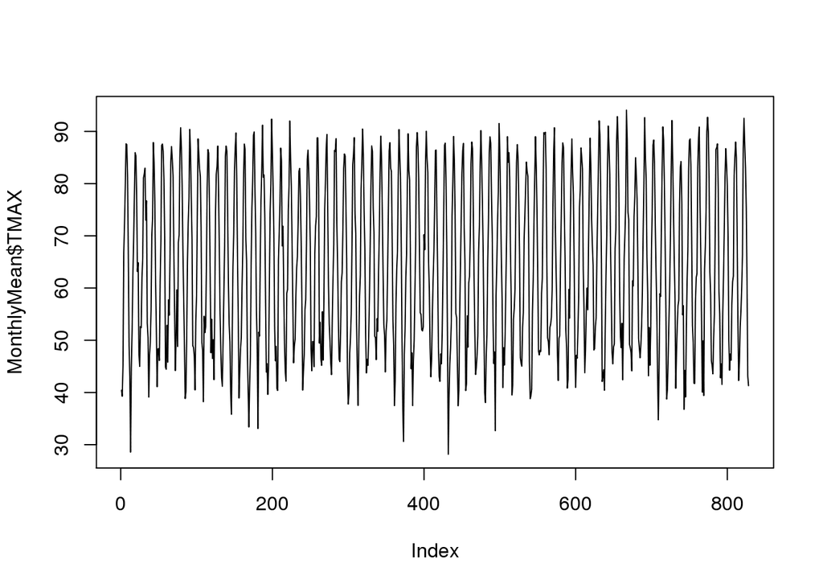

```r
plot(MonthlyMean$TMAX, ty='l')
```

below is sd

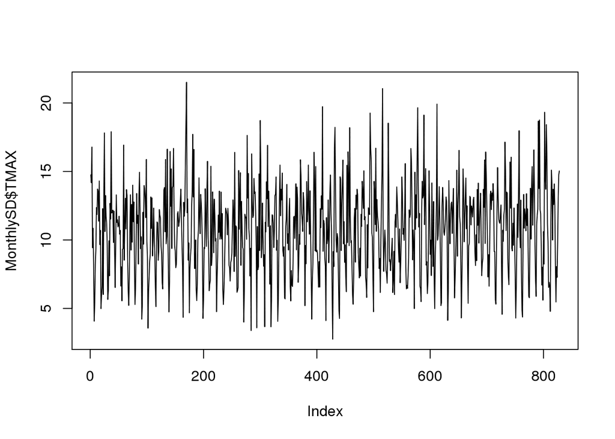

```r
plot(MonthlySD$TMAX, ty='l')
```

```r
plot(TMAX~ NewDate, data=MonthlySD, ty='l')
SD.lm <- lm(TMAX~NewDate, data=MonthlySD)
summary(SD.lm)
```

```
##
## Call:
## lm(formula = TMAX ~ NewDate, data = MonthlySD)
##
## Residuals:
##     Min      1Q  Median      3Q     Max
## -8.0043 -2.1451  0.0356  2.1668 10.9694
##
## Coefficients:
##              Estimate Std. Error t value Pr(>|t|)
## (Intercept) -9.384188  11.068716  -0.848   0.3968
## NewDate      0.010156   0.005583   1.819   0.0693 .
## ---
## Signif. codes:  0 '***' 0.001 '**' 0.01 '*' 0.05 '.' 0.1 ' ' 1
##
## Residual standard error: 3.202 on 826 degrees of freedom
## Multiple R-squared:  0.00399,    Adjusted R-squared:  0.002784
## F-statistic: 3.309 on 1 and 826 DF,  p-value: 0.06927
```

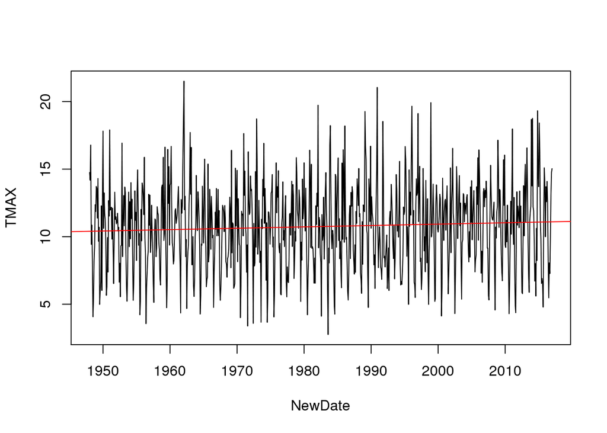

```r
abline(coef(SD.lm), col="red")
```

### Selecting for 1 Month – May

Perhaps, we can get a better handle on this stuff if we analyze for just one month at a time – certainly easier to visualize!

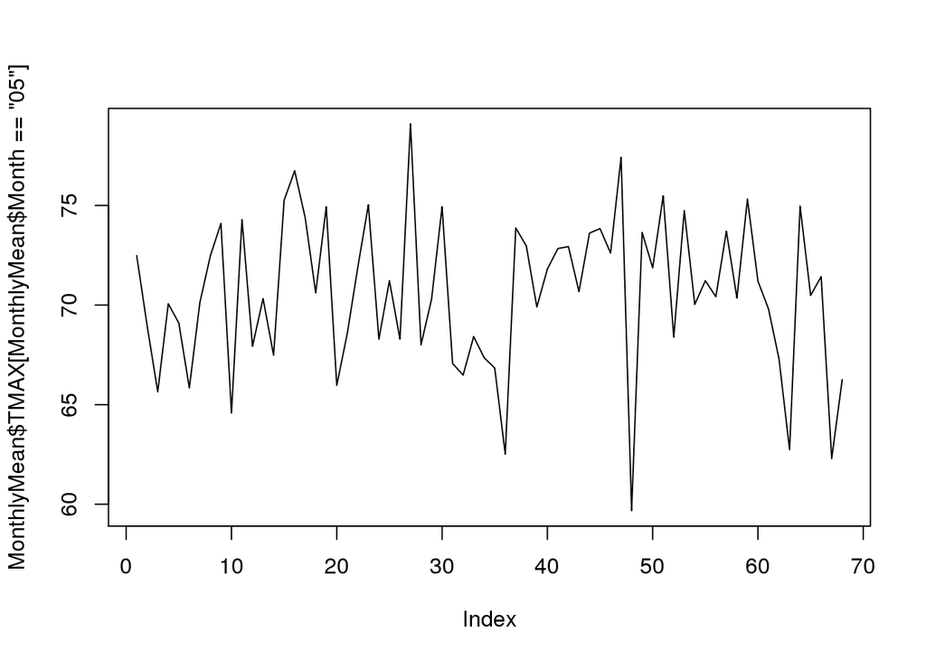

```r
plot(MonthlyMean$TMAX[MonthlyMean$Month=="05"], ty='l')
```

```r
plot(TMAX~YEAR, data=MonthlyMean[MonthlyMean$Month=="05",], ty='l')
May.lm <- lm(TMAX~YEAR, data=MonthlyMean[MonthlyMean$Month=="05",])
summary(May.lm)
```

```
##
## Call:
## lm(formula = TMAX ~ YEAR, data = MonthlyMean[MonthlyMean$Month ==
##     "05", ])
##
## Residuals:
##      Min       1Q   Median       3Q      Max
## -10.8604  -2.3922  -0.0083   3.1329   8.4931
##
## Coefficients:
##              Estimate Std. Error t value Pr(>|t|)
## (Intercept) 76.790895  47.273637   1.624    0.109
## YEAR        -0.003134   0.023855  -0.131    0.896
##
## Residual standard error: 3.893 on 66 degrees of freedom
## Multiple R-squared:  0.0002615,  Adjusted R-squared:  -0.01489
## F-statistic: 0.01726 on 1 and 66 DF,  p-value: 0.8959
```

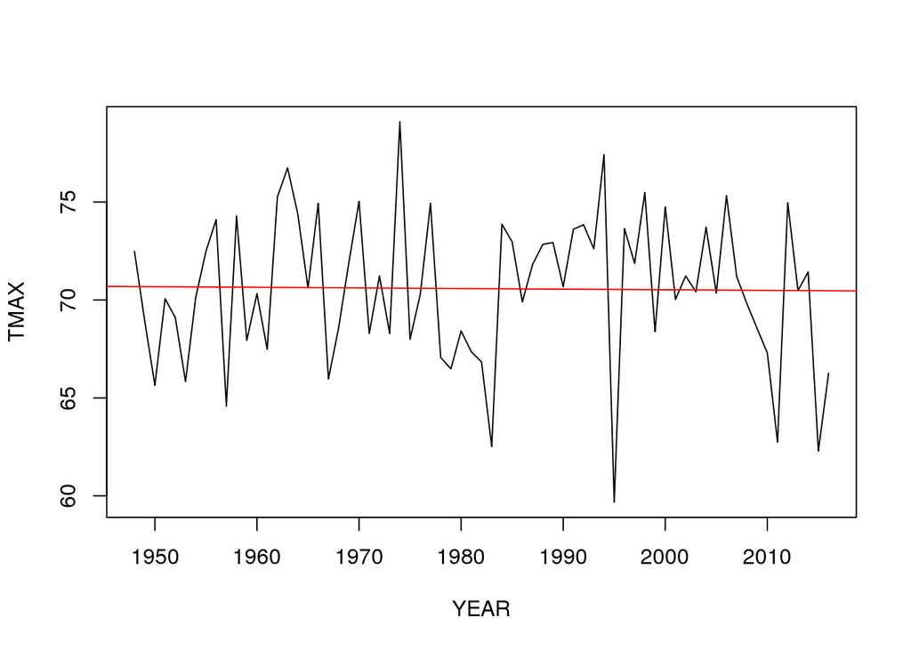

```r
abline(coef(May.lm), col="red")
```

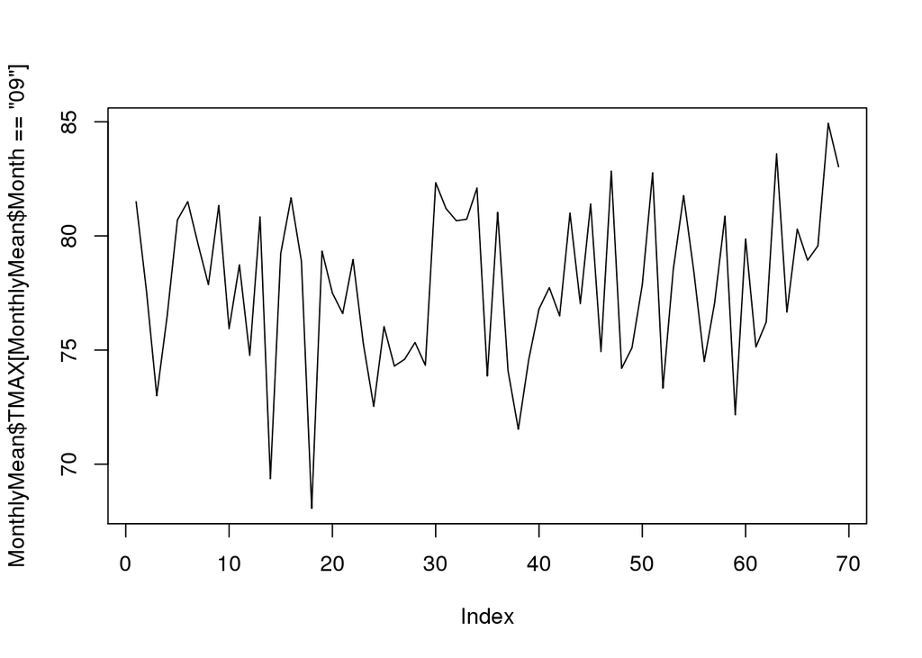

```r
plot(MonthlyMean$TMAX[MonthlyMean$Month=="09"], ty='l')
```

```r
plot(TMAX~YEAR, data=MonthlyMean[MonthlyMean$Month=="09",], ty='l')
Sep.lm <- lm(TMAX~YEAR, data=MonthlyMean[MonthlyMean$Month=="09",])
summary(Sep.lm)
```

```
##
## Call:
## lm(formula = TMAX ~ YEAR, data = MonthlyMean[MonthlyMean$Month ==
##     "09", ])
##
## Residuals:
##     Min      1Q  Median      3Q     Max
## -9.3042 -2.9896  0.1298  3.0215  6.3472
##
## Coefficients:
##             Estimate Std. Error t value Pr(>|t|)
## (Intercept) 29.61115   42.39200   0.699    0.487
## YEAR         0.02431    0.02139   1.136    0.260
##
## Residual standard error: 3.538 on 67 degrees of freedom
## Multiple R-squared:  0.01891,    Adjusted R-squared:  0.004268
## F-statistic: 1.291 on 1 and 67 DF,  p-value: 0.2598
```

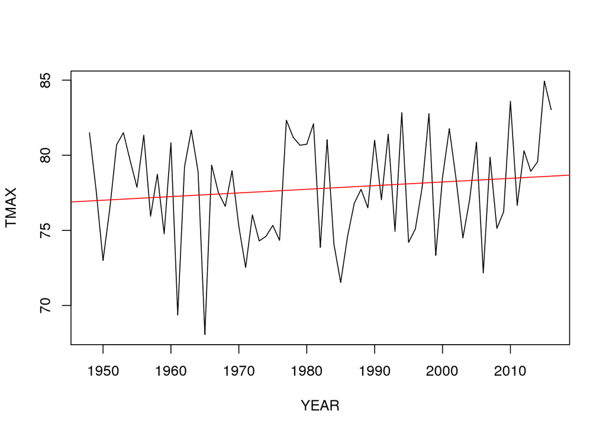

```r
abline(coef(Sep.lm), col="red")
```

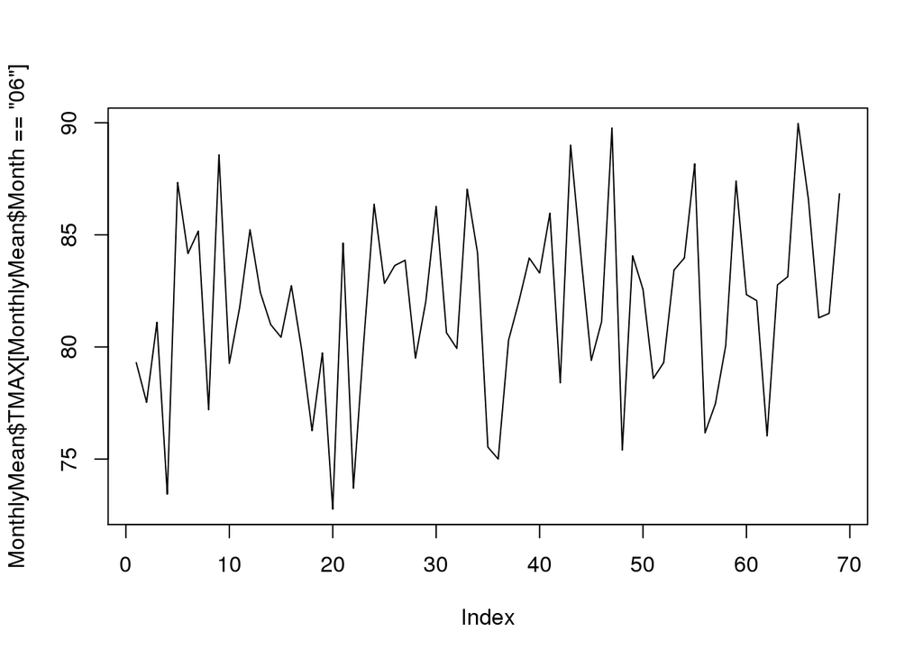

```r
plot(MonthlyMean$TMAX[MonthlyMean$Month=="06"], ty='l')
```

```r
plot(TMAX~YEAR, data=MonthlyMean[MonthlyMean$Month=="06",], ty='l')
June.lm <- lm(TMAX~YEAR, data=MonthlyMean[MonthlyMean$Month=="06",])
summary(June.lm)
```

```
##
## Call:
## lm(formula = TMAX ~ YEAR, data = MonthlyMean[MonthlyMean$Month ==
##     "06", ])
##
## Residuals:
##     Min      1Q  Median      3Q     Max
## -8.5461 -2.0953  0.0849  2.3928  7.6423
##
## Coefficients:
##             Estimate Std. Error t value Pr(>|t|)
## (Intercept) 11.84854   48.19161   0.246    0.807
## YEAR         0.03531    0.02431   1.452    0.151
##
## Residual standard error: 4.022 on 67 degrees of freedom
## Multiple R-squared:  0.03053,    Adjusted R-squared:  0.01606
## F-statistic:  2.11 on 1 and 67 DF,  p-value: 0.151
```

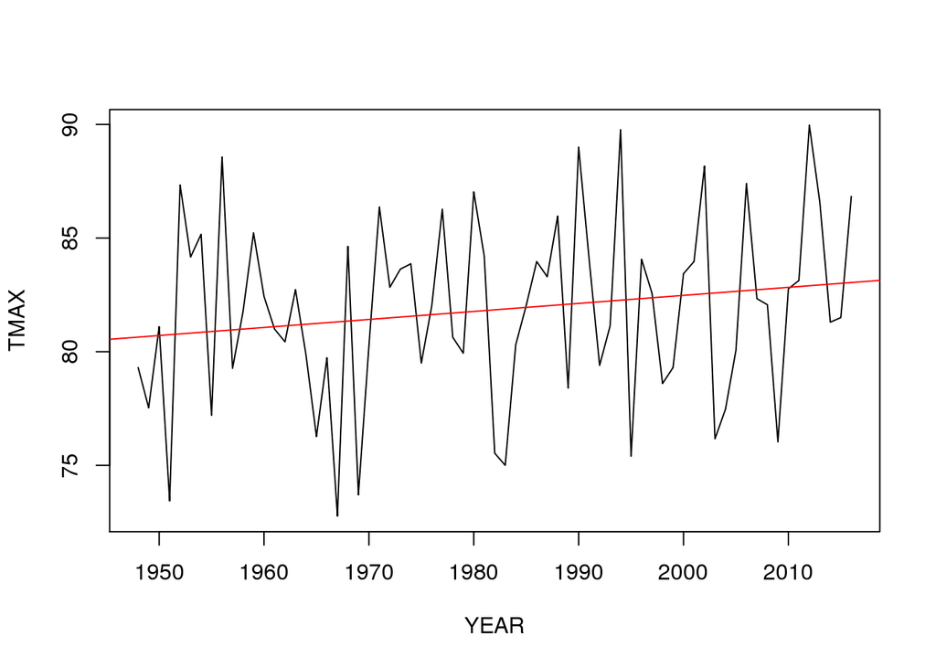

```r
abline(coef(June.lm), col="red")
```

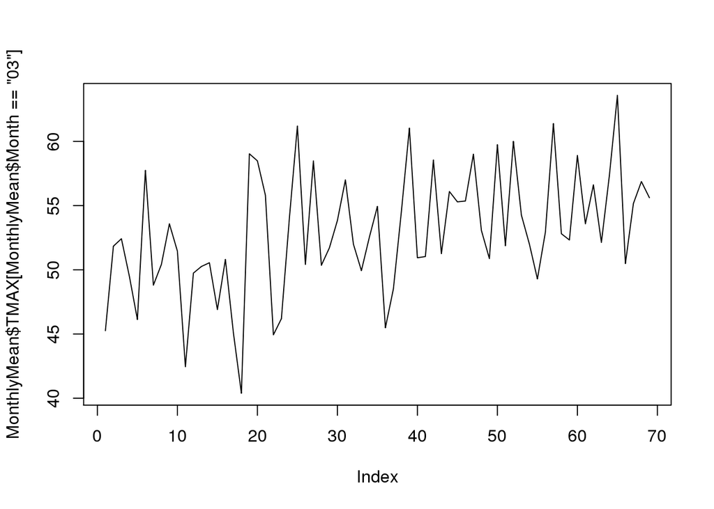

```r
plot(MonthlyMean$TMAX[MonthlyMean$Month=="03"], ty='l')
```

```r
plot(TMAX~YEAR, data=MonthlyMean[MonthlyMean$Month=="03",], ty='l')
Mar.lm <- lm(TMAX~YEAR, data=MonthlyMean[MonthlyMean$Month=="03",])
summary(Mar.lm)
```

```
##
## Call:
## lm(formula = TMAX ~ YEAR, data = MonthlyMean[MonthlyMean$Month ==
##     "03", ])
##
## Residuals:
##      Min       1Q   Median       3Q      Max
## -10.7646  -2.7325  -0.3707   2.3606   9.3097
##
## Coefficients:
##               Estimate Std. Error t value Pr(>|t|)
## (Intercept) -154.38274   51.58739  -2.993 0.003870 **
## YEAR           0.10460    0.02603   4.019 0.000151 ***
## ---
## Signif. codes:  0 '***' 0.001 '**' 0.01 '*' 0.05 '.' 0.1 ' ' 1
##
## Residual standard error: 4.306 on 67 degrees of freedom
## Multiple R-squared:  0.1942, Adjusted R-squared:  0.1822
## F-statistic: 16.15 on 1 and 67 DF,  p-value: 0.0001506
```

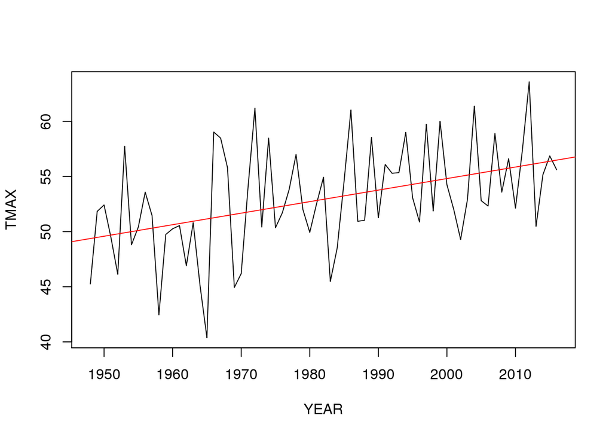

```r
abline(coef(Mar.lm), col="red")
```

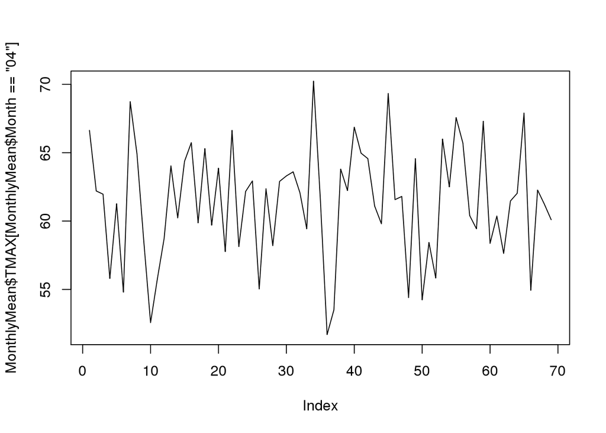

```r
plot(MonthlyMean$TMAX[MonthlyMean$Month=="04"], ty='l')
```

```r
plot(TMAX~YEAR, data=MonthlyMean[MonthlyMean$Month=="04",], ty='l')
Apr.lm <- lm(TMAX~YEAR, data=MonthlyMean[MonthlyMean$Month=="04",])
summary(Apr.lm)
```

```
##
## Call:
## lm(formula = TMAX ~ YEAR, data = MonthlyMean[MonthlyMean$Month ==
##     "04", ])
##
## Residuals:
##     Min      1Q  Median      3Q     Max
## -9.6870 -2.6959  0.3487  3.1024  8.8580
##
## Coefficients:
##              Estimate Std. Error t value Pr(>|t|)
## (Intercept) 49.797165  51.048447   0.975    0.333
## YEAR         0.005845   0.025755   0.227    0.821
##
## Residual standard error: 4.261 on 67 degrees of freedom
## Multiple R-squared:  0.000768,   Adjusted R-squared:  -0.01415
## F-statistic: 0.0515 on 1 and 67 DF,  p-value: 0.8212
```

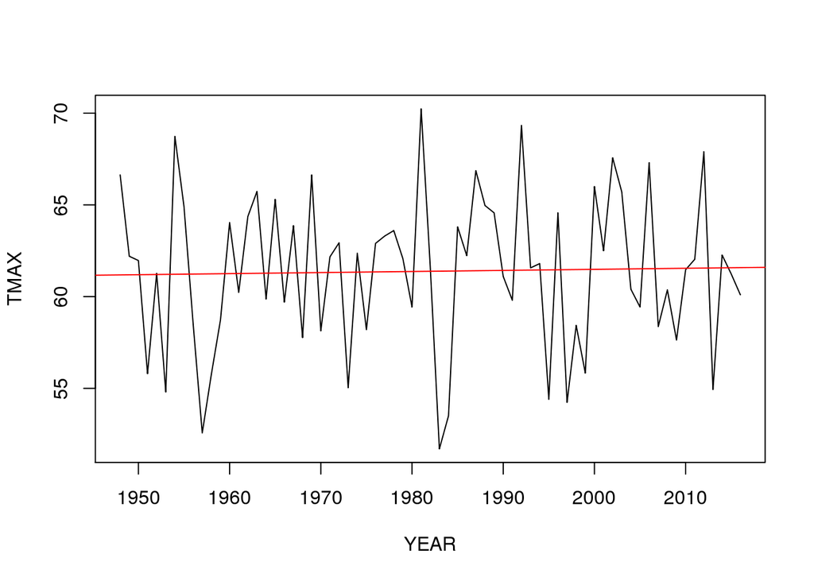

```r
abline(coef(Apr.lm), col="red")
```

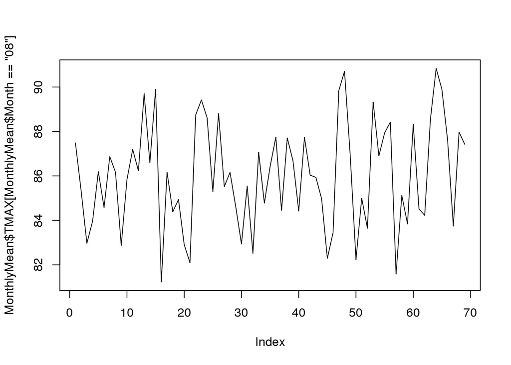

```r
plot(MonthlyMean$TMAX[MonthlyMean$Month=="08"], ty='l')
```

```r
plot(TMAX~YEAR, data=MonthlyMean[MonthlyMean$Month=="08",], ty='l')
Aug.lm <- lm(TMAX~YEAR, data=MonthlyMean[MonthlyMean$Month=="08",])
summary(Aug.lm)
```

```
##
## Call:
## lm(formula = TMAX ~ YEAR, data = MonthlyMean[MonthlyMean$Month ==
##     "08", ])
##
## Residuals:
##     Min      1Q  Median      3Q     Max
## -4.8465 -1.6131  0.2632  1.6047  4.4456
##
## Coefficients:
##             Estimate Std. Error t value Pr(>|t|)
## (Intercept) 50.11504   28.26901   1.773   0.0808 .
## YEAR         0.01812    0.01426   1.270   0.2083
## ---
## Signif. codes:  0 '***' 0.001 '**' 0.01 '*' 0.05 '.' 0.1 ' ' 1
##
## Residual standard error: 2.36 on 67 degrees of freedom
## Multiple R-squared:  0.02352,    Adjusted R-squared:  0.00895
## F-statistic: 1.614 on 1 and 67 DF,  p-value: 0.2083
```

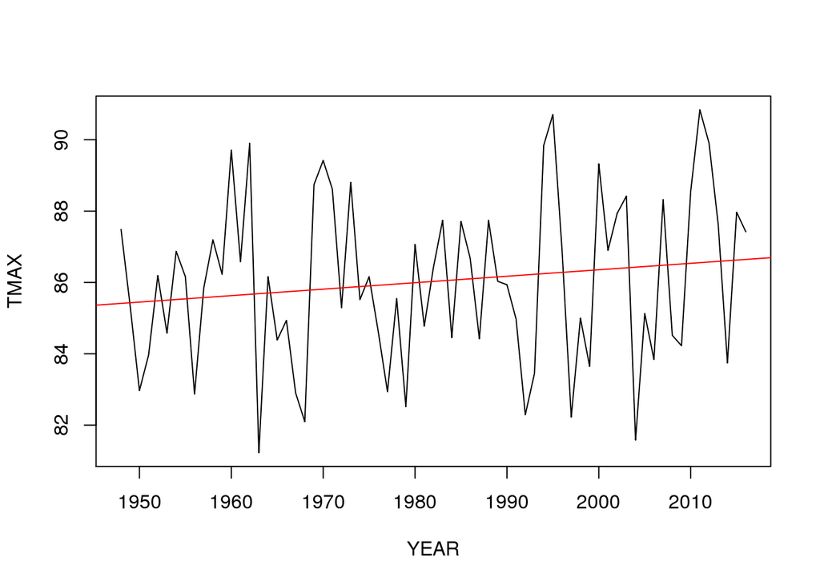

```r
abline(coef(Aug.lm), col="red")
```

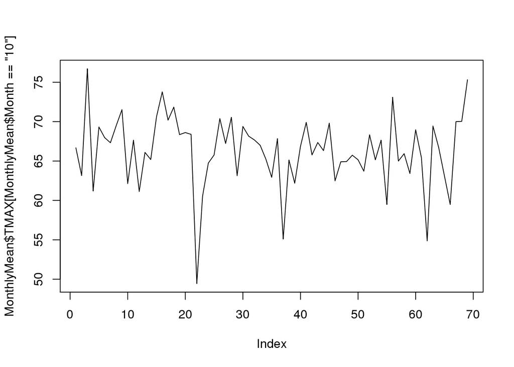

```r
plot(MonthlyMean$TMAX[MonthlyMean$Month=="10"], ty='l')
```

```r
plot(TMAX~YEAR, data=MonthlyMean[MonthlyMean$Month=="10",], ty='l')
Oct.lm <- lm(TMAX~YEAR, data=MonthlyMean[MonthlyMean$Month=="10",])
summary(Oct.lm)
```

```
##
## Call:
## lm(formula = TMAX ~ YEAR, data = MonthlyMean[MonthlyMean$Month ==
##     "10", ])
##
## Residuals:
##      Min       1Q   Median       3Q      Max
## -17.1345  -1.7990   0.3972   2.5811   9.7992
##
## Coefficients:
##              Estimate Std. Error t value Pr(>|t|)
## (Intercept) 111.11010   54.36389   2.044   0.0449 *
## YEAR         -0.02261    0.02743  -0.824   0.4126
## ---
## Signif. codes:  0 '***' 0.001 '**' 0.01 '*' 0.05 '.' 0.1 ' ' 1
##
## Residual standard error: 4.538 on 67 degrees of freedom
## Multiple R-squared:  0.01004,    Adjusted R-squared:  -0.004732
## F-statistic: 0.6797 on 1 and 67 DF,  p-value: 0.4126
```

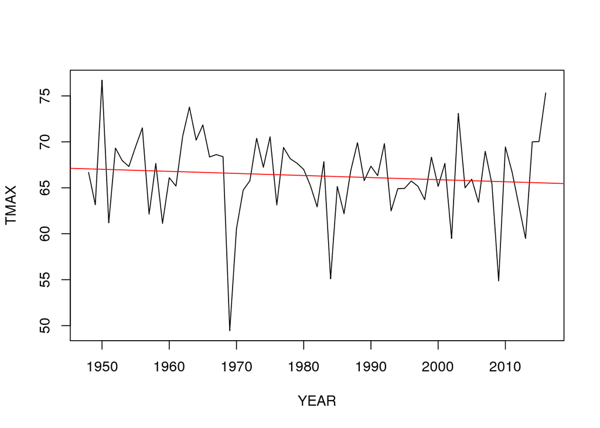

```r
abline(coef(Oct.lm), col="red")
```

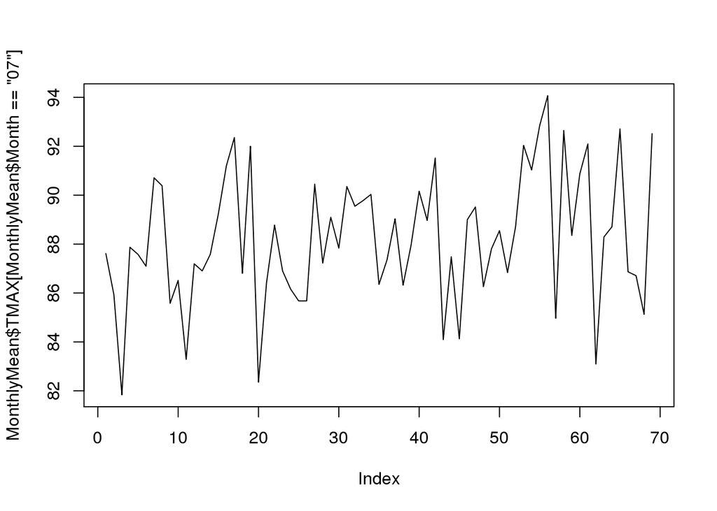

```r
plot(MonthlyMean$TMAX[MonthlyMean$Month=="07"], ty='l')
```

```r
plot(TMAX~YEAR, data=MonthlyMean[MonthlyMean$Month=="07",], ty='l')
Jul.lm <- lm(TMAX~YEAR, data=MonthlyMean[MonthlyMean$Month=="07",])
summary(Jul.lm)
```

```
##
## Call:
## lm(formula = TMAX ~ YEAR, data = MonthlyMean[MonthlyMean$Month ==
##     "07", ])
##
## Residuals:
##    Min     1Q Median     3Q    Max
## -6.050 -1.677 -0.185  1.793  5.125
##
## Coefficients:
##             Estimate Std. Error t value Pr(>|t|)
## (Intercept) 19.96715   31.33906   0.637   0.5262
## YEAR         0.03443    0.01581   2.178   0.0329 *
## ---
## Signif. codes:  0 '***' 0.001 '**' 0.01 '*' 0.05 '.' 0.1 ' ' 1
##
## Residual standard error: 2.616 on 67 degrees of freedom
## Multiple R-squared:  0.06611,    Adjusted R-squared:  0.05218
## F-statistic: 4.743 on 1 and 67 DF,  p-value: 0.03294
```

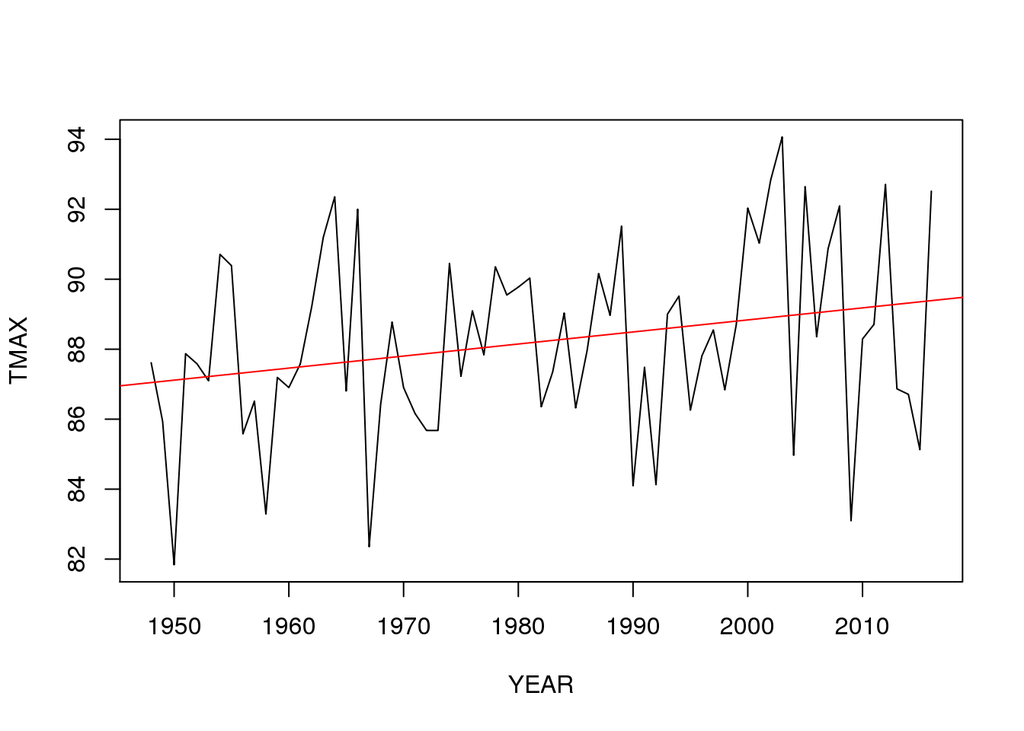

```r
abline(coef(Jul.lm), col="red")
```

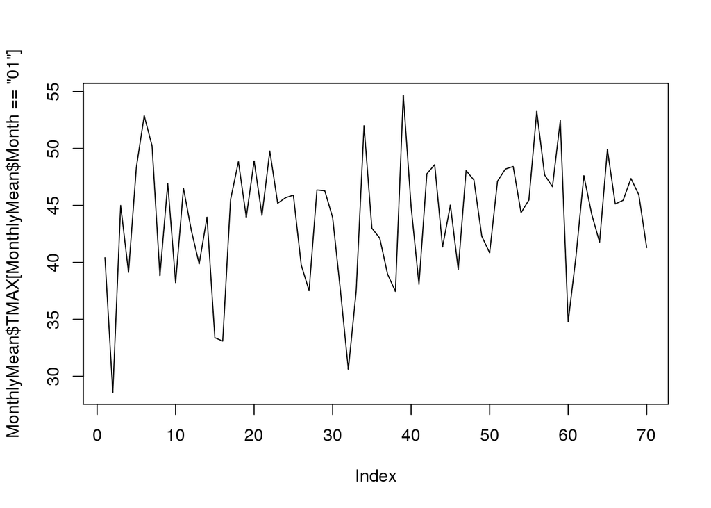

```r
plot(MonthlyMean$TMAX[MonthlyMean$Month=="01"], ty='l')
```

```r
plot(TMAX~YEAR, data=MonthlyMean[MonthlyMean$Month=="01",], ty='l')
Jan.lm <- lm(TMAX~YEAR, data=MonthlyMean[MonthlyMean$Month=="01",])
summary(Jan.lm)
```

```
##
## Call:
## lm(formula = TMAX ~ YEAR, data = MonthlyMean[MonthlyMean$Month ==
##     "01", ])
##
## Residuals:
##      Min       1Q   Median       3Q      Max
## -13.5538  -3.6378   0.6495   3.2444  10.5626
##
## Coefficients:
##              Estimate Std. Error t value Pr(>|t|)
## (Intercept) -62.18209   61.56625  -1.010   0.3161
## YEAR          0.05352    0.03105   1.724   0.0893 .
## ---
## Signif. codes:  0 '***' 0.001 '**' 0.01 '*' 0.05 '.' 0.1 ' ' 1
##
## Residual standard error: 5.25 on 68 degrees of freedom
## Multiple R-squared:  0.04186,    Adjusted R-squared:  0.02777
## F-statistic: 2.971 on 1 and 68 DF,  p-value: 0.08933
```

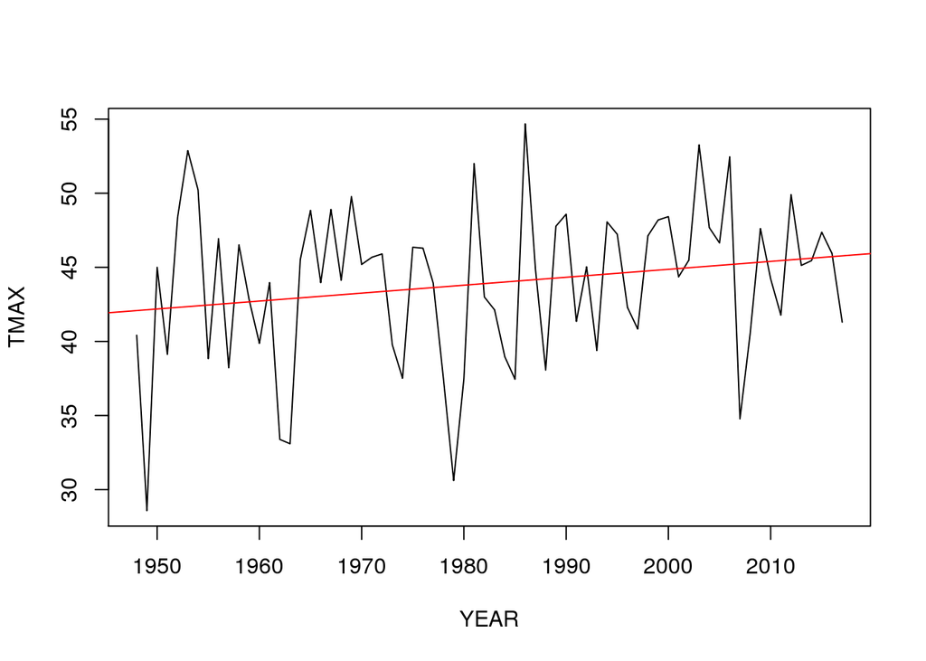

```r
abline(coef(Jan.lm), col="red")
```

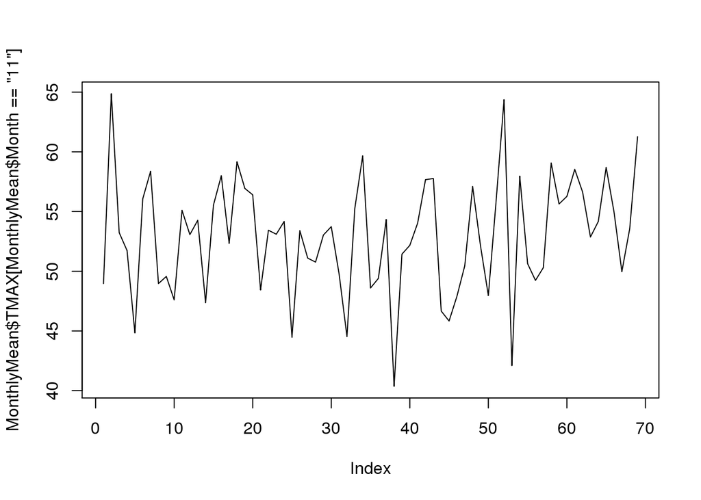

```r
plot(MonthlyMean$TMAX[MonthlyMean$Month=="11"], ty='l')
```

```r
plot(TMAX~YEAR, data=MonthlyMean[MonthlyMean$Month=="11",], ty='l')
Nov.lm <- lm(TMAX~YEAR, data=MonthlyMean[MonthlyMean$Month=="11",])
summary(Nov.lm)
```

```
##
## Call:
## lm(formula = TMAX ~ YEAR, data = MonthlyMean[MonthlyMean$Month ==
##     "11", ])
##
## Residuals:
##      Min       1Q   Median       3Q      Max
## -12.6565  -3.2125   0.4739   3.1025  12.7706
##
## Coefficients:
##             Estimate Std. Error t value Pr(>|t|)
## (Intercept)  1.90294   58.63966   0.032    0.974
## YEAR         0.02575    0.02958   0.870    0.387
##
## Residual standard error: 4.894 on 67 degrees of freedom
## Multiple R-squared:  0.01118,    Adjusted R-squared:  -0.003575
## F-statistic: 0.7578 on 1 and 67 DF,  p-value: 0.3871
```

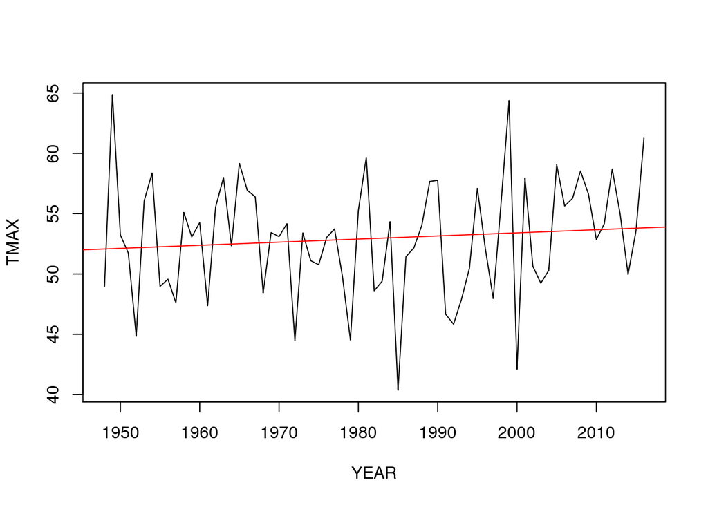

```r
abline(coef(Nov.lm), col="red")
```

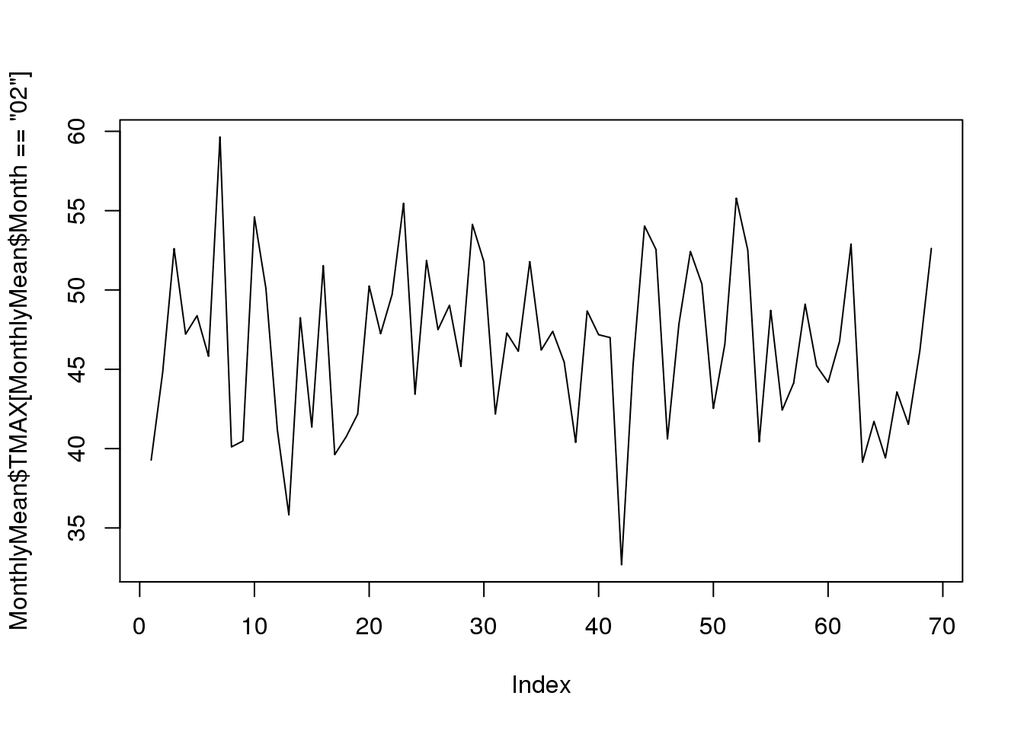

```r
plot(MonthlyMean$TMAX[MonthlyMean$Month=="02"], ty='l')
```

```r
plot(TMAX~YEAR, data=MonthlyMean[MonthlyMean$Month=="02",], ty='l')
Feb.lm <- lm(TMAX~YEAR, data=MonthlyMean[MonthlyMean$Month=="02",])
summary(Feb.lm)
```

```
##
## Call:
## lm(formula = TMAX ~ YEAR, data = MonthlyMean[MonthlyMean$Month ==
##     "02", ])
##
## Residuals:
##      Min       1Q   Median       3Q      Max
## -13.7601  -4.3965   0.3043   3.5385  12.7701
##
## Coefficients:
##             Estimate Std. Error t value Pr(>|t|)
## (Intercept) 71.10913   63.39779   1.122    0.266
## YEAR        -0.01240    0.03199  -0.388    0.699
##
## Residual standard error: 5.292 on 67 degrees of freedom
## Multiple R-squared:  0.002239,   Adjusted R-squared:  -0.01265
## F-statistic: 0.1504 on 1 and 67 DF,  p-value: 0.6994
```